# Risk Factor Analysis

## Outcome Variable

**Outcome Variable:** whz

## Predictor Variables

**Intervention Variable:** fhtcm

**Adjustment Set:**

unadjusted

## Stratifying Variables

The analysis was stratified on these variable(s):

- agecat
- studyid
- country

## Data Summary

| agecat | studyid | country | fhtcm | n_cell | n |
| --- | --- | --- | --- | --- | --- |
| Birth | COHORTS | GUATEMALA | >=167 cm | 26 | 192 |
| Birth | COHORTS | GUATEMALA | <162 cm | 112 | 192 |
| Birth | COHORTS | GUATEMALA | [162-167) cm | 54 | 192 |
| Birth | Keneba | GAMBIA | >=167 cm | 733 | 1114 |
| Birth | Keneba | GAMBIA | <162 cm | 83 | 1114 |
| Birth | Keneba | GAMBIA | [162-167) cm | 298 | 1114 |
| Birth | PROBIT | BELARUS | >=167 cm | 11672 | 12461 |
| Birth | PROBIT | BELARUS | <162 cm | 168 | 12461 |
| Birth | PROBIT | BELARUS | [162-167) cm | 621 | 12461 |
| Birth | SAS-CompFeed | INDIA | >=167 cm | 312 | 657 |
| Birth | SAS-CompFeed | INDIA | <162 cm | 159 | 657 |
| Birth | SAS-CompFeed | INDIA | [162-167) cm | 186 | 657 |
| 6 months | COHORTS | GUATEMALA | >=167 cm | 44 | 336 |
| 6 months | COHORTS | GUATEMALA | <162 cm | 198 | 336 |
| 6 months | COHORTS | GUATEMALA | [162-167) cm | 94 | 336 |
| 6 months | Keneba | GAMBIA | >=167 cm | 979 | 1510 |
| 6 months | Keneba | GAMBIA | <162 cm | 113 | 1510 |
| 6 months | Keneba | GAMBIA | [162-167) cm | 418 | 1510 |
| 6 months | PROBIT | BELARUS | >=167 cm | 11142 | 11891 |
| 6 months | PROBIT | BELARUS | <162 cm | 156 | 11891 |
| 6 months | PROBIT | BELARUS | [162-167) cm | 593 | 11891 |
| 6 months | SAS-CompFeed | INDIA | >=167 cm | 370 | 807 |
| 6 months | SAS-CompFeed | INDIA | <162 cm | 193 | 807 |
| 6 months | SAS-CompFeed | INDIA | [162-167) cm | 244 | 807 |
| 6 months | SAS-FoodSuppl | INDIA | >=167 cm | 102 | 371 |
| 6 months | SAS-FoodSuppl | INDIA | <162 cm | 148 | 371 |
| 6 months | SAS-FoodSuppl | INDIA | [162-167) cm | 121 | 371 |
| 24 months | COHORTS | GUATEMALA | >=167 cm | 72 | 532 |
| 24 months | COHORTS | GUATEMALA | <162 cm | 311 | 532 |
| 24 months | COHORTS | GUATEMALA | [162-167) cm | 149 | 532 |
| 24 months | Keneba | GAMBIA | >=167 cm | 823 | 1298 |
| 24 months | Keneba | GAMBIA | <162 cm | 96 | 1298 |
| 24 months | Keneba | GAMBIA | [162-167) cm | 379 | 1298 |
| 24 months | PROBIT | BELARUS | >=167 cm | 3386 | 3608 |
| 24 months | PROBIT | BELARUS | <162 cm | 52 | 3608 |
| 24 months | PROBIT | BELARUS | [162-167) cm | 170 | 3608 |

The following strata were considered:

- agecat: 24 months, studyid: COHORTS, country: GUATEMALA
- agecat: 24 months, studyid: Keneba, country: GAMBIA
- agecat: 24 months, studyid: PROBIT, country: BELARUS
- agecat: 6 months, studyid: COHORTS, country: GUATEMALA
- agecat: 6 months, studyid: Keneba, country: GAMBIA
- agecat: 6 months, studyid: PROBIT, country: BELARUS
- agecat: 6 months, studyid: SAS-CompFeed, country: INDIA
- agecat: 6 months, studyid: SAS-FoodSuppl, country: INDIA
- agecat: Birth, studyid: COHORTS, country: GUATEMALA
- agecat: Birth, studyid: Keneba, country: GAMBIA
- agecat: Birth, studyid: PROBIT, country: BELARUS
- agecat: Birth, studyid: SAS-CompFeed, country: INDIA

## Methods Detail

We’re interested in the causal parameters $E[Y_a]$ for all values of $a \in \mathcal{A}$. These parameters represent the mean outcome if, possibly contrary to fact, we intervened to set all units to have $A=a$. Under the randomization and positivity assumptions, these are identified by the statistical parameters $\psi_a=E_W[E_{Y|A,W}(Y|A=a,W)]$. In addition, we’re interested in the mean of $Y$, $E[Y]$ under no intervention (the observed mean). We will estimate these parameters by using SuperLearner to fit the relevant likelihood factors – $E_{Y|A,W}(Y|A=a,W)$ and $p(A=a|W)$, and then updating our likelihood fit using a joint TMLE.

For unadjusted analyses ($W=\{\}$), initial likelihoods were estimated using Lrnr_glm to estimate the simple $E(Y|A)$ and Lrnr_mean to estimate $p(A)$. For adjusted analyses, a small library containing Lrnr_glmnet, Lrnr_xgboost, and Lrnr_mean was used.

Having estimated these parameters, we will then use the delta method to estimate relative risks and attributable risks relative to a prespecified baseline level of $A$.

# Results Detail

## Results Plots

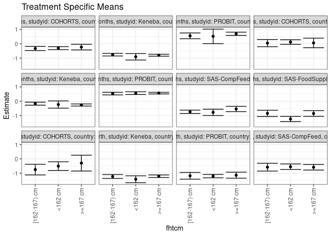

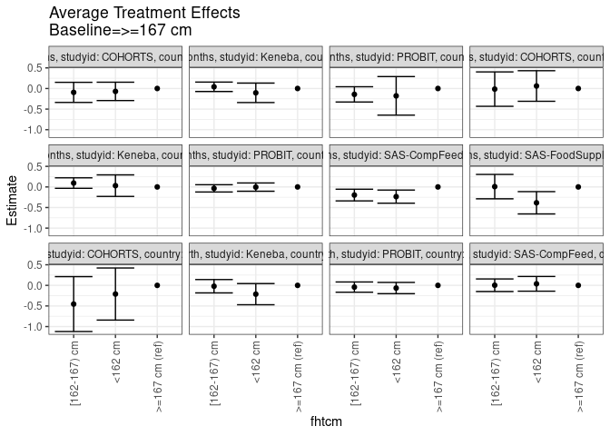

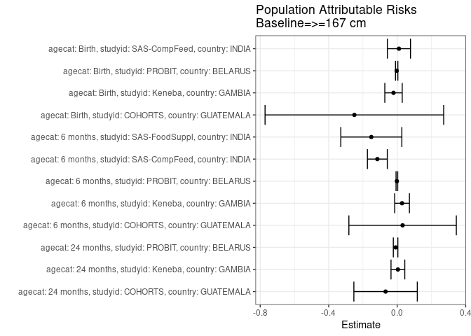

## Results Table

### Parameter: TSM

| agecat | studyid | country | intervention_level | baseline_level | estimate | ci_lower | ci_upper |
| --- | --- | --- | --- | --- | --- | --- | --- |
| Birth | COHORTS | GUATEMALA | >=167 cm | NA | -0.2950000 | -0.8487177 | 0.2587177 |
| Birth | COHORTS | GUATEMALA | <162 cm | NA | -0.5050000 | -0.8100277 | -0.1999723 |
| Birth | COHORTS | GUATEMALA | [162-167) cm | NA | -0.7485185 | -1.1187628 | -0.3782742 |
| Birth | Keneba | GAMBIA | >=167 cm | NA | -1.2089700 | -1.2986743 | -1.1192657 |
| Birth | Keneba | GAMBIA | <162 cm | NA | -1.4219880 | -1.6625777 | -1.1813982 |
| Birth | Keneba | GAMBIA | [162-167) cm | NA | -1.2297987 | -1.3648518 | -1.0947455 |
| Birth | PROBIT | BELARUS | >=167 cm | NA | -1.1389445 | -1.3493081 | -0.9285808 |
| Birth | PROBIT | BELARUS | <162 cm | NA | -1.2038690 | -1.3223287 | -1.0854094 |
| Birth | PROBIT | BELARUS | [162-167) cm | NA | -1.1807568 | -1.4178493 | -0.9436644 |
| Birth | SAS-CompFeed | INDIA | >=167 cm | NA | -0.5835256 | -0.7781318 | -0.3889194 |
| Birth | SAS-CompFeed | INDIA | <162 cm | NA | -0.5457862 | -0.7373729 | -0.3541994 |
| Birth | SAS-CompFeed | INDIA | [162-167) cm | NA | -0.5798387 | -0.8524197 | -0.3072577 |
| 6 months | COHORTS | GUATEMALA | >=167 cm | NA | 0.0593182 | -0.2752300 | 0.3938664 |
| 6 months | COHORTS | GUATEMALA | <162 cm | NA | 0.1200505 | -0.0408976 | 0.2809986 |
| 6 months | COHORTS | GUATEMALA | [162-167) cm | NA | 0.0443617 | -0.2056781 | 0.2944015 |
| 6 months | Keneba | GAMBIA | >=167 cm | NA | -0.2555462 | -0.3276333 | -0.1834591 |
| 6 months | Keneba | GAMBIA | <162 cm | NA | -0.2244292 | -0.4756016 | 0.0267432 |
| 6 months | Keneba | GAMBIA | [162-167) cm | NA | -0.1615736 | -0.2667740 | -0.0563731 |
| 6 months | PROBIT | BELARUS | >=167 cm | NA | 0.5755035 | 0.5163579 | 0.6346491 |
| 6 months | PROBIT | BELARUS | <162 cm | NA | 0.5714103 | 0.4738817 | 0.6689388 |
| 6 months | PROBIT | BELARUS | [162-167) cm | NA | 0.5408600 | 0.4484371 | 0.6332829 |
| 6 months | SAS-CompFeed | INDIA | >=167 cm | NA | -0.5344459 | -0.7190779 | -0.3498140 |
| 6 months | SAS-CompFeed | INDIA | <162 cm | NA | -0.7696891 | -0.9886229 | -0.5507553 |
| 6 months | SAS-CompFeed | INDIA | [162-167) cm | NA | -0.7314549 | -0.8485996 | -0.6143102 |
| 6 months | SAS-FoodSuppl | INDIA | >=167 cm | NA | -0.8487255 | -1.0485698 | -0.6488811 |
| 6 months | SAS-FoodSuppl | INDIA | <162 cm | NA | -1.2337162 | -1.4165764 | -1.0508561 |
| 6 months | SAS-FoodSuppl | INDIA | [162-167) cm | NA | -0.8409917 | -1.0594145 | -0.6225690 |
| 24 months | COHORTS | GUATEMALA | >=167 cm | NA | -0.2325000 | -0.4293212 | -0.0356788 |
| 24 months | COHORTS | GUATEMALA | <162 cm | NA | -0.3030547 | -0.4073057 | -0.1988036 |
| 24 months | COHORTS | GUATEMALA | [162-167) cm | NA | -0.3271812 | -0.4710574 | -0.1833050 |
| 24 months | Keneba | GAMBIA | >=167 cm | NA | -0.8005502 | -0.8684558 | -0.7326447 |
| 24 months | Keneba | GAMBIA | <162 cm | NA | -0.9058108 | -1.1324581 | -0.6791634 |
| 24 months | Keneba | GAMBIA | [162-167) cm | NA | -0.7595976 | -0.8512159 | -0.6679793 |
| 24 months | PROBIT | BELARUS | >=167 cm | NA | 0.6972007 | 0.5831936 | 0.8112079 |
| 24 months | PROBIT | BELARUS | <162 cm | NA | 0.5180769 | 0.0114535 | 1.0247004 |
| 24 months | PROBIT | BELARUS | [162-167) cm | NA | 0.5544216 | 0.3536815 | 0.7551617 |

### Parameter: E(Y)

| agecat | studyid | country | intervention_level | baseline_level | estimate | ci_lower | ci_upper |
| --- | --- | --- | --- | --- | --- | --- | --- |
| Birth | COHORTS | GUATEMALA | NA | NA | -0.5450521 | -0.7653906 | -0.3247135 |
| Birth | Keneba | GAMBIA | NA | NA | -1.2304129 | -1.3019732 | -1.1588526 |
| Birth | PROBIT | BELARUS | NA | NA | -1.1419035 | -1.3515776 | -0.9322295 |
| Birth | SAS-CompFeed | INDIA | NA | NA | -0.5733486 | -0.7681703 | -0.3785268 |
| 6 months | COHORTS | GUATEMALA | NA | NA | 0.0909226 | -0.0348636 | 0.2167089 |
| 6 months | Keneba | GAMBIA | NA | NA | -0.2272039 | -0.2854286 | -0.1689793 |
| 6 months | PROBIT | BELARUS | NA | NA | 0.5737221 | 0.5157281 | 0.6317162 |
| 6 months | SAS-CompFeed | INDIA | NA | NA | -0.6502726 | -0.7957520 | -0.5047932 |
| 6 months | SAS-FoodSuppl | INDIA | NA | NA | -0.9997844 | -1.1172238 | -0.8823449 |
| 24 months | COHORTS | GUATEMALA | NA | NA | -0.3002632 | -0.3780672 | -0.2224591 |
| 24 months | Keneba | GAMBIA | NA | NA | -0.7963776 | -0.8498028 | -0.7429525 |
| 24 months | PROBIT | BELARUS | NA | NA | 0.6878917 | 0.5705107 | 0.8052728 |

### Parameter: ATE

| agecat | studyid | country | intervention_level | baseline_level | estimate | ci_lower | ci_upper |
| --- | --- | --- | --- | --- | --- | --- | --- |
| Birth | COHORTS | GUATEMALA | >=167 cm | >=167 cm | 0.0000000 | 0.0000000 | 0.0000000 |
| Birth | COHORTS | GUATEMALA | <162 cm | >=167 cm | -0.2100000 | -0.8421750 | 0.4221750 |
| Birth | COHORTS | GUATEMALA | [162-167) cm | >=167 cm | -0.4535185 | -1.1196147 | 0.2125777 |
| Birth | Keneba | GAMBIA | >=167 cm | >=167 cm | 0.0000000 | 0.0000000 | 0.0000000 |
| Birth | Keneba | GAMBIA | <162 cm | >=167 cm | -0.2130180 | -0.4697870 | 0.0437510 |
| Birth | Keneba | GAMBIA | [162-167) cm | >=167 cm | -0.0208287 | -0.1829590 | 0.1413016 |
| Birth | PROBIT | BELARUS | >=167 cm | >=167 cm | 0.0000000 | 0.0000000 | 0.0000000 |
| Birth | PROBIT | BELARUS | <162 cm | >=167 cm | -0.0649246 | -0.2018241 | 0.0719749 |
| Birth | PROBIT | BELARUS | [162-167) cm | >=167 cm | -0.0418124 | -0.1662018 | 0.0825770 |
| Birth | SAS-CompFeed | INDIA | >=167 cm | >=167 cm | 0.0000000 | 0.0000000 | 0.0000000 |
| Birth | SAS-CompFeed | INDIA | <162 cm | >=167 cm | 0.0377395 | -0.1411898 | 0.2166687 |
| Birth | SAS-CompFeed | INDIA | [162-167) cm | >=167 cm | 0.0036869 | -0.1490130 | 0.1563868 |
| 6 months | COHORTS | GUATEMALA | >=167 cm | >=167 cm | 0.0000000 | 0.0000000 | 0.0000000 |
| 6 months | COHORTS | GUATEMALA | <162 cm | >=167 cm | 0.0607323 | -0.3105179 | 0.4319826 |
| 6 months | COHORTS | GUATEMALA | [162-167) cm | >=167 cm | -0.0149565 | -0.4326195 | 0.4027065 |
| 6 months | Keneba | GAMBIA | >=167 cm | >=167 cm | 0.0000000 | 0.0000000 | 0.0000000 |
| 6 months | Keneba | GAMBIA | <162 cm | >=167 cm | 0.0311170 | -0.2301954 | 0.2924293 |
| 6 months | Keneba | GAMBIA | [162-167) cm | >=167 cm | 0.0939726 | -0.0335566 | 0.2215018 |
| 6 months | PROBIT | BELARUS | >=167 cm | >=167 cm | 0.0000000 | 0.0000000 | 0.0000000 |
| 6 months | PROBIT | BELARUS | <162 cm | >=167 cm | -0.0040932 | -0.1046374 | 0.0964509 |
| 6 months | PROBIT | BELARUS | [162-167) cm | >=167 cm | -0.0346435 | -0.1226293 | 0.0533424 |
| 6 months | SAS-CompFeed | INDIA | >=167 cm | >=167 cm | 0.0000000 | 0.0000000 | 0.0000000 |
| 6 months | SAS-CompFeed | INDIA | <162 cm | >=167 cm | -0.2352432 | -0.3948119 | -0.0756744 |
| 6 months | SAS-CompFeed | INDIA | [162-167) cm | >=167 cm | -0.1970090 | -0.3390937 | -0.0549242 |
| 6 months | SAS-FoodSuppl | INDIA | >=167 cm | >=167 cm | 0.0000000 | 0.0000000 | 0.0000000 |
| 6 months | SAS-FoodSuppl | INDIA | <162 cm | >=167 cm | -0.3849907 | -0.6558700 | -0.1141114 |
| 6 months | SAS-FoodSuppl | INDIA | [162-167) cm | >=167 cm | 0.0077338 | -0.2883174 | 0.3037849 |
| 24 months | COHORTS | GUATEMALA | >=167 cm | >=167 cm | 0.0000000 | 0.0000000 | 0.0000000 |
| 24 months | COHORTS | GUATEMALA | <162 cm | >=167 cm | -0.0705547 | -0.2932806 | 0.1521713 |
| 24 months | COHORTS | GUATEMALA | [162-167) cm | >=167 cm | -0.0946812 | -0.3384822 | 0.1491198 |
| 24 months | Keneba | GAMBIA | >=167 cm | >=167 cm | 0.0000000 | 0.0000000 | 0.0000000 |
| 24 months | Keneba | GAMBIA | <162 cm | >=167 cm | -0.1052605 | -0.3418618 | 0.1313408 |
| 24 months | Keneba | GAMBIA | [162-167) cm | >=167 cm | 0.0409526 | -0.0730872 | 0.1549924 |
| 24 months | PROBIT | BELARUS | >=167 cm | >=167 cm | 0.0000000 | 0.0000000 | 0.0000000 |
| 24 months | PROBIT | BELARUS | <162 cm | >=167 cm | -0.1791238 | -0.6477912 | 0.2895435 |
| 24 months | PROBIT | BELARUS | [162-167) cm | >=167 cm | -0.1427792 | -0.3282349 | 0.0426766 |

### Parameter: PAR

| agecat | studyid | country | intervention_level | baseline_level | estimate | ci_lower | ci_upper |
| --- | --- | --- | --- | --- | --- | --- | --- |
| Birth | COHORTS | GUATEMALA | >=167 cm | NA | -0.2500521 | -0.7716976 | 0.2715934 |
| Birth | Keneba | GAMBIA | >=167 cm | NA | -0.0214429 | -0.0722193 | 0.0293334 |
| Birth | PROBIT | BELARUS | >=167 cm | NA | -0.0029591 | -0.0098771 | 0.0039590 |
| Birth | SAS-CompFeed | INDIA | >=167 cm | NA | 0.0101771 | -0.0574118 | 0.0777660 |
| 6 months | COHORTS | GUATEMALA | >=167 cm | NA | 0.0316044 | -0.2821337 | 0.3453426 |
| 6 months | Keneba | GAMBIA | >=167 cm | NA | 0.0283422 | -0.0146503 | 0.0713347 |
| 6 months | PROBIT | BELARUS | >=167 cm | NA | -0.0017814 | -0.0067258 | 0.0031631 |
| 6 months | SAS-CompFeed | INDIA | >=167 cm | NA | -0.1158267 | -0.1739254 | -0.0577280 |
| 6 months | SAS-FoodSuppl | INDIA | >=167 cm | NA | -0.1510589 | -0.3292986 | 0.0271809 |
| 24 months | COHORTS | GUATEMALA | >=167 cm | NA | -0.0677632 | -0.2529831 | 0.1174568 |
| 24 months | Keneba | GAMBIA | >=167 cm | NA | 0.0041726 | -0.0360514 | 0.0443966 |
| 24 months | PROBIT | BELARUS | >=167 cm | NA | -0.0093090 | -0.0225605 | 0.0039425 |